# Simple Linear Regression Analysis for Prediction of the % of Student based on the Number of Study Hour

Monone Damilola Elizabeth

2024-07-16

## Introduction

This document performs a simple linear regression analysis to predict student scores based on study hours.

# Data Loading

```r
Hours_Scores <- read_excel("Hours_Scores.xlsx")

# Print the first few rows of the data
head(Hours_Scores)
```

```
## # A tibble: 6 × 2
##   Hours Scores
##   <dbl>  <dbl>
## 1   2.5     21
## 2   5.1     47
## 3   3.2     27
## 4   8.5     75
## 5   3.5     30
## 6   1.5     20
```

## Exploratory Data Analysis (EDA)

To check the structure and summary statistics of the data.

```r
# View the first few rows of the data
head(Hours_Scores)
```

```
## # A tibble: 6 × 2
##   Hours Scores
##   <dbl>  <dbl>
## 1   2.5     21
## 2   5.1     47
## 3   3.2     27
## 4   8.5     75
## 5   3.5     30
## 6   1.5     20
```

```r
# Summary statistics
summary(Hours_Scores)
```

```
##      Hours           Scores
##  Min.   :1.100   Min.   :17.00
##  1st Qu.:2.700   1st Qu.:30.00
##  Median :4.800   Median :47.00
##  Mean   :5.012   Mean   :51.48
##  3rd Qu.:7.400   3rd Qu.:75.00
##  Max.   :9.200   Max.   :95.00
```

```r
# Structure of the data
str(Hours_Scores)
```

```
## tibble [25 × 2] (S3: tbl_df/tbl/data.frame)
##  $ Hours : num [1:25] 2.5 5.1 3.2 8.5 3.5 1.5 9.2 5.5 8.3 2.7 ...
##  $ Scores: num [1:25] 21 47 27 75 30 20 88 60 81 25 ...
```

# Visualization of the data

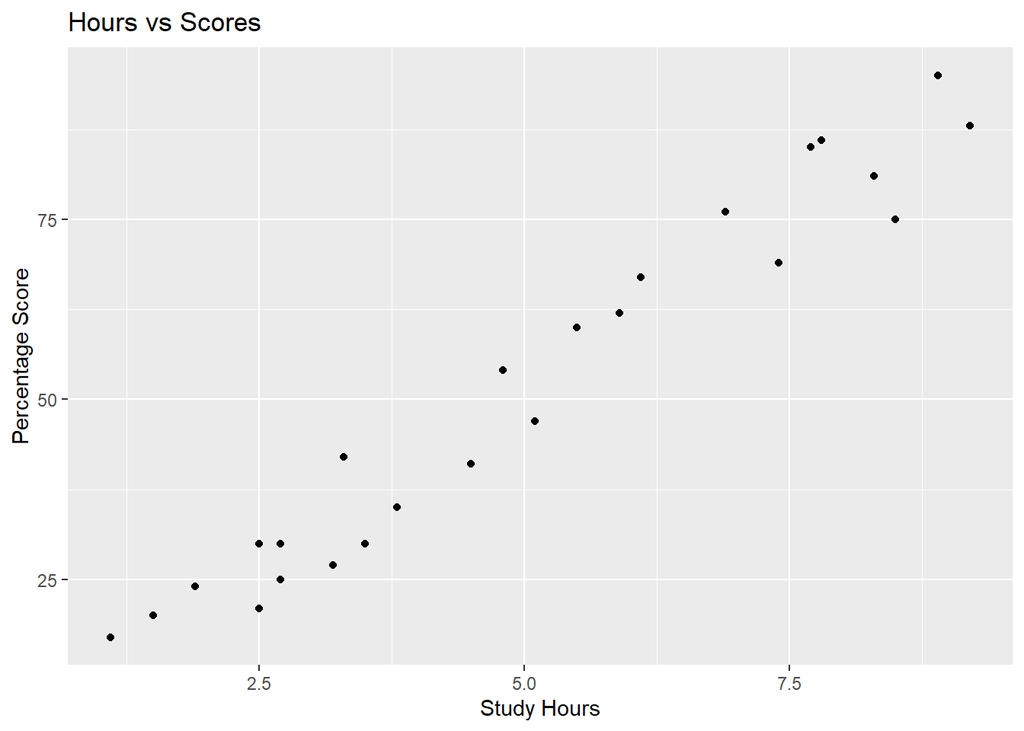

```r
ggplot(Hours_Scores, aes(x=Hours, y=Scores)) +
  geom_point() +
  labs(title="Hours vs Scores", x="Study Hours", y="Percentage Score")
```

The plottted scatter plot of the data is to visualize the relationship between study hours and scores.

## Linear Regression Model

```r
model <- lm(Scores ~ Hours, data=Hours_Scores)

# Summary of the model
print(summary(model))
```

```
##
## Call:
## lm(formula = Scores ~ Hours, data = Hours_Scores)
##
## Residuals:
##     Min      1Q  Median      3Q     Max
## -10.578  -5.340   1.839   4.593   7.265
##
## Coefficients:
##             Estimate Std. Error t value Pr(>|t|)
## (Intercept)   2.4837     2.5317   0.981    0.337
## Hours         9.7758     0.4529  21.583   <2e-16 ***
## ---
## Signif. codes:  0 '***' 0.001 '**' 0.01 '*' 0.05 '.' 0.1 ' ' 1
##
## Residual standard error: 5.603 on 23 degrees of freedom
## Multiple R-squared:  0.9529, Adjusted R-squared:  0.9509
## F-statistic: 465.8 on 1 and 23 DF,  p-value: < 2.2e-16
```

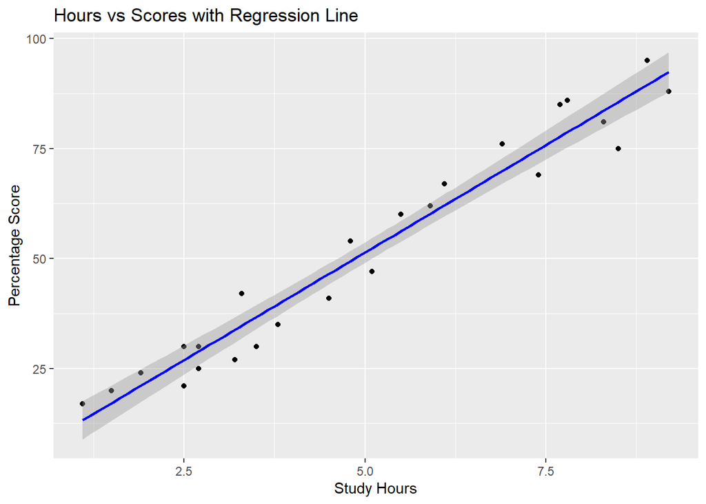

```r
# Plot the regression line
ggplot(Hours_Scores, aes(x=Hours, y=Scores)) +
  geom_point() +
  geom_smooth(method="lm", col="blue") +
  labs(title="Hours vs Scores with Regression Line", x="Study Hours", y="Percentage Score")
```

The plotted regression line and the scatter points shows a possitive realtionship between the study hours and the percentage scores of the students.

## Predictions and Residuals

```r
predicted_scores <- predict(model, newdata=Hours_Scores)

# Add predictions to the data frame
Hours_Scores$Predicted_Scores <- predicted_scores

# Calculate residuals
Hours_Scores$Residuals <- Hours_Scores$Scores - Hours_Scores$Predicted_Scores

# Print the first few rows to verify predictions and residuals
print(head(Hours_Scores))
```

```
## # A tibble: 6 × 4
##   Hours Scores Predicted_Scores Residuals
##   <dbl>  <dbl>            <dbl>     <dbl>
## 1   2.5     21             26.9     -5.92
## 2   5.1     47             52.3     -5.34
## 3   3.2     27             33.8     -6.77
## 4   8.5     75             85.6    -10.6
## 5   3.5     30             36.7     -6.70
## 6   1.5     20             17.1      2.85
```

## Observed vs Predicted Plot

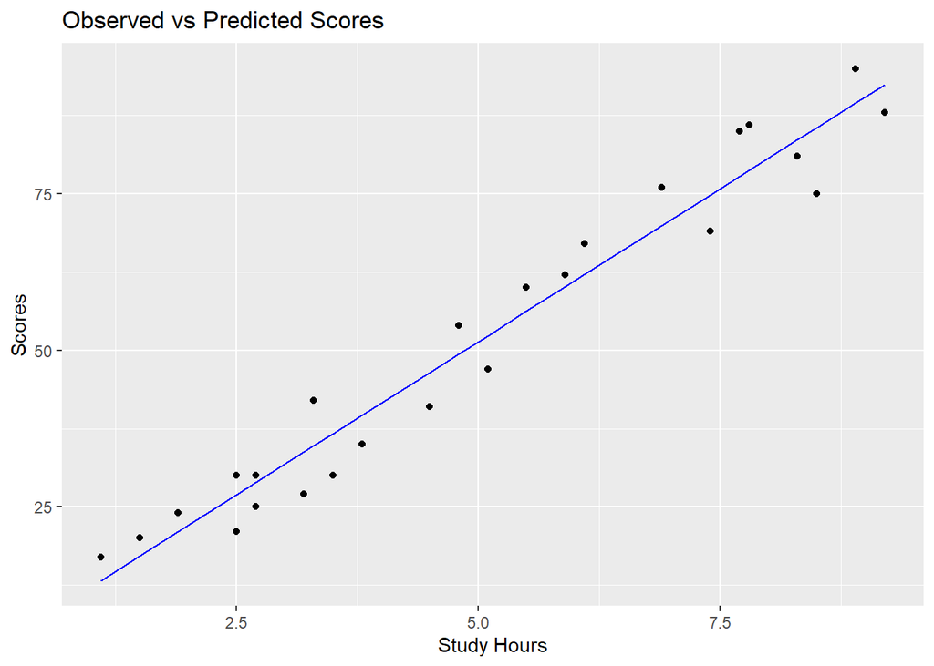

```r
ggplot(Hours_Scores, aes(x=Hours, y=Scores)) +
  geom_point() +
  geom_line(aes(y=Predicted_Scores), color="blue") +
  labs(title="Observed vs Predicted Scores", x="Study Hours", y="Scores")
```

## Model Evaluation

```r
# Root Mean Squared Error (RMSE)
rmse <- sqrt(mean(Hours_Scores$Residuals^2))
print(paste("RMSE:", rmse))
```

```
## [1] "RMSE: 5.37426557859262"
```

```r
# Mean Absolute Error (MAE)
mae <- mean(abs(Hours_Scores$Residuals))
print(paste("MAE:", mae))
```

```
## [1] "MAE: 4.97280531986637"
```

## Predicting New Data

```r
new_data <- data.frame(Hours = 9.25)
predicted_score <- predict(model, newdata=new_data)
print(paste("Predicted score for a student who studies 9.25 hours per day:", predicted_score))
```

```
## [1] "Predicted score for a student who studies 9.25 hours per day: 92.9098547701573"
```

## Conclusion

I performed a simple linear regression analysis to predict student scores based on study hours. I evaluated the model using RMSE and MAE, and made predictions for new data. From the analysis, we can draw the following conclusions: 1. The analysis confirms that increasing the number of study hours has a positive impact on student scores. This relationship is statistically significant and can be used to predict scores based on study hours. 2. The linear regression model fits the data reasonably well, as indicated by the R-squared value and the residual standard error. However, it is important to consider other potential variables that might influence student scores, which are not included in this simple model. 3. The RMSE and MAE values provide a quantitative measure of the model’s prediction accuracy. While these metrics indicate that the model performs reasonably well, there is still some room for improvement, as reflected by the residuals. 4. The model can be used to make informed predictions about student scores based on the number of study hours. For example, a student studying 9.25 hours per day is predicted to achieve a specific score, which can help in planning study schedules and setting academic goals.